# Lab 3

Jonathan DeGardner

9/27/2020

```r
#install.packages('readxl')
dat <- readxl::read_xls("C:\\Users\\Jonny DeGardner\\Desktop\\Cawlige\\S.S1\\DS 202\\ds202_lab3\\extract1.tar\\extract1\\GSS.xls")
str(dat)
```

```
## tibble [64,816 x 11] (S3: tbl_df/tbl/data.frame)
##  $ Gss year for this respondent       : num [1:64816] 1972 1972 1972 1972 1972 ...
##  $ General happiness                  : chr [1:64816] "Not too happy" "Not too happy" "Pretty happy" "Not too happy" ...
##  $ Political party affiliation        : chr [1:64816] "Ind,near dem" "Not str democrat" "Independent" "Not str democrat" ...
##  $ Respondents sex                    : chr [1:64816] "Female" "Male" "Female" "Female" ...
##  $ Highest year of school completed   : chr [1:64816] "16" "10" "12" "17" ...
##  $ Marital status                     : chr [1:64816] "Never married" "Married" "Married" "Married" ...
##  $ Govt or private employee           : chr [1:64816] "Not applicable" "Not applicable" "Not applicable" "Not applicable" ...
##  $ R self-emp or works for somebody   : chr [1:64816] "Someone else" "Someone else" "Someone else" "Someone else" ...
##  $ Number of hours usually work a week: chr [1:64816] "Not applicable" "Not applicable" "Not applicable" "Not applicable" ...
##  $ Respondent id number               : num [1:64816] 1 2 3 4 5 6 7 8 9 10 ...
##  $ Ballot used for interview          : chr [1:64816] "Not applicable" "Not applicable" "Not applicable" "Not applicable" ...
```

## Question 1

```r
library(dplyr)
pol_affil <- select(dat, 'Political party affiliation')
edu <- as.numeric(dat$`Highest year of school completed`)
ind1 <- filter(dat, pol_affil == 'Independent')
ind2 <- filter(dat, pol_affil == 'Ind,near dem')
ind3 <- filter(dat, pol_affil == 'Ind,near rep')
ind <- c(ind1, ind2, ind3)

dem1 <- filter(dat, pol_affil == 'Strong democrat')
dem2 <- filter(dat, pol_affil == 'Not str democrat')
dem <- c(dem1, dem2)

rep1 <- filter(dat, pol_affil == 'Strong republican')
rep2 <- filter(dat, pol_affil == 'Not str republication')
rep <- c(rep1, rep2)

#mean(ind$`Highest year of school completed`)
#mean(dem$`Highest year of school completed`)
#mean(rep$`Highest year of school completed`)
```

I am not sure what I am doing wrong here, but I could not get an output.

## Question 2

Since I could not get an output from the previous question, I did not code this one, but I will run you through my thought process in case it can award me any type of partial credit. For the 3 sections of political affiliation I would first find the median for each affiliation. After that I would take just the values that are greater than the median for that specific affiliation. Once that is complete, I would add the outputs for each affiliation into a new data frame and print the structure of that data frame.

## Question 3

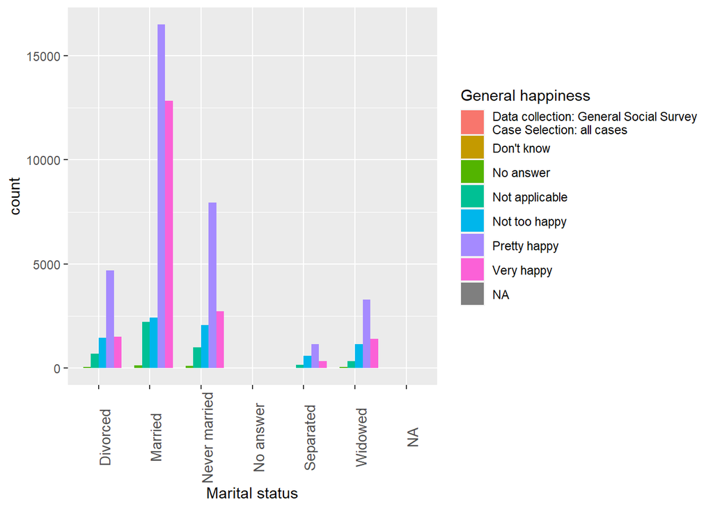

```r
library(ggplot2)
a <- ggplot(dat, aes(x=`Marital status`, ..count..)) + geom_bar(aes(fill=`General happiness`), position='dodge')
a + theme(axis.text.x = element_text(size=10, angle=90))
```

Based on the visual, the happiest people (based on very happy and pretty happy) are either married or never married. Following those, the next happiest people are divorced, then widowed, and then separated.